# Project 8

# Targeted Maximum Likelihood Estimation

## Causal Diagram

Using ggdag and daggity, draw a directed acylcic graph (DAG) that describes the relationships between the outcome, treatment, and covariates/predictors. Note, if you think there are covariates that are not related to other variables in the dataset, note this by either including them as freestanding nodes or by omitting them and noting omissions in your discussion.

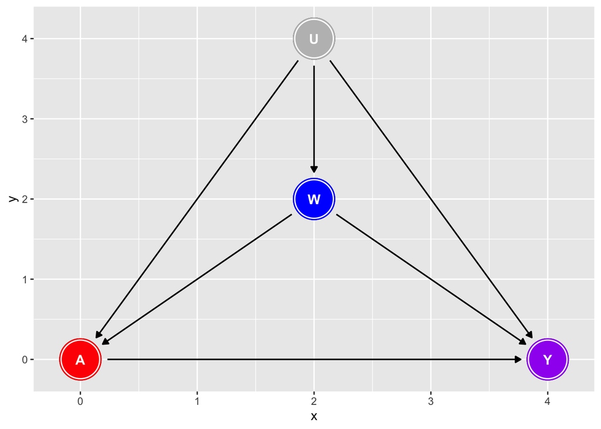

```r
# DAG for TMLE

## Y ~ mortality
## A ~ blood_pressure_medication
## W ~ age + sex_at_birth + simplified_race + college_educ + income_thousands + bmi + blood_pressure + chol

dag <- dagify(Y ~ A + W + U,
              A ~ W + U,
              W ~ U,
              exposure = "A",
              outcome = "Y") %>%
  tidy_dagitty() %>%
  pretty_dag()

dag %>%
  ggdag() +
  geom_dag_node(aes(color = color)) +
  geom_dag_text(col = "white") +
  theme(legend.position = "none") +
  scale_color_manual(values=c("red","grey", "blue", "purple"))
```

## TMLE Estimation

```r
# TMLE Estimation
set.seed(123)

Y <- heart_disease$mortality
A <- heart_disease$blood_pressure_medication
W <- heart_disease %>%
  select(age, sex_at_birth, simplified_race, college_educ, income_thousands, bmi, blood_pressure, chol)

tmle_fit <-
  tmle::tmle(Y = Y,
             A = A,
             W = W,
             Q.SL.library = lib,
             g.SL.library = lib)
```

```r
# view results
tmle_fit
```

```
##  Marginal mean under treatment (EY1)
##    Parameter Estimate:  0.20475
##    Estimated Variance:  3.0603e-05
##               p-value:  <2e-16
##     95% Conf Interval:  (0.1939, 0.21559)
##
##  Marginal mean under comparator (EY0)
##    Parameter Estimate:  0.56603
##    Estimated Variance:  2.7658e-05
##               p-value:  <2e-16
##     95% Conf Interval:  (0.55572, 0.57634)
##
##  Additive Effect
##    Parameter Estimate:  -0.36128
##    Estimated Variance:  5.8114e-05
##               p-value:  <2e-16
##     95% Conf Interval:  (-0.37623, -0.34634)
##
##  Additive Effect among the Treated
##    Parameter Estimate:  -0.74814
##    Estimated Variance:  2.0752e-05
##               p-value:  <2e-16
##     95% Conf Interval:  (-0.75707, -0.73921)
##
##  Additive Effect among the Controls
##    Parameter Estimate:  -0.5653
##    Estimated Variance:  2.7749e-05
##               p-value:  <2e-16
##     95% Conf Interval:  (-0.57563, -0.55498)
```

## Discussion Questions

```r
# What is a "double robust" estimator? Why does it provide a guarantee of consistency if either the outcome model or propensity score model is correctly specified? Or in other words, why does mispecifying one of the models not break the analysis? \textbf{Hint}: When answering this question, think about how your introductory statistics courses emphasized using theory to determine the correct outcome model, and in this course how we explored the benefits of matching.

# A doubly robust estimator reduces the risk of model misspecification while being efficient (in terms of variance). It provides consistency even when the model might be misspecified because it combines the outcome model and the propensity score model, so if one model is misspecified, the model can still produce consistent estimates if the other model is correctly specified. If the outcome model is misspecified, the model can still recover the true causal effect because of the propensity score model, a benefit of matching.
```

# LTMLE Estimation

Now imagine that everything you measured up until now was in “time period 1”. Some people either choose not to or otherwise lack access to medication in that time period, but do start taking the medication in time period 2. Imagine we measure covariates like BMI, blood pressure, and cholesterol at that time for everyone in the study (indicated by a “_2” after the covariate name).

## Causal Diagram

Update your causal diagram to incorporate this new information. : If your groups divides up sections and someone is working on LTMLE separately from TMLE then just draw a causal diagram even if it does not match the one you specified above.

: Check out slide 27 from Maya’s lecture, or slides 15-17 from Dave’s second slide deck in week 8 on matching.

: Keep in mind that any of the variables that end in “_2” are likely affected by both the previous covariates and the first treatment when drawing your DAG.

```r
# DAG for TMLE
## I couldn't get dagify to work correctly with the wrapper, so I just drew the dag.
knitr::include_graphics("DAG.pdf")
```

[figure not shown]

```r
#dag <- dagify(Y ~ A0 + W0 + A1 + W1 + U,
#              A1 ~ W0 + A0 + U,
#              W1 ~ W0 + U,
#              A0 ~ W0 + U,
#              W0 ~ U,
#              exposure = "A1",
#              outcome = "Y") %>%
#  tidy_dagitty() %>%
#  pretty_dag()
#
#dag %>%
#  ggdag() +
#  geom_dag_node(aes(color = color)) +
#  geom_dag_text(col = "white") +
#  theme(legend.position = "none") +
#  scale_color_manual(values=c("red","grey", "blue", "purple"))
```

## LTMLE Estimation

Use the `ltmle` package for this section. First fit a “naive model” that control for the time-dependent confounding. Then run a LTMLE model that does control for any time dependent confounding. Follow the same steps as in the TMLE section. Do you see a difference between the two estimates?

```r
dt.ltmle <- heart_disease %>%
  rename(W0.1 = age,
         W0.2 = sex_at_birth,
         W0.3 = simplified_race,
         W0.4 = college_educ,
         W0.5 = income_thousands,
         W0.6 = bmi,
         W0.7 = blood_pressure,
         W0.8 = chol,
         A0 = blood_pressure_medication,
         W1.1 = bmi_2,
         W1.2 = blood_pressure_2,
         W1.3 = chol_2,
         A1 = blood_pressure_medication_2,
         Y = mortality) %>%
  select(W0.1, W0.2, W0.3, W0.4, W0.5, W0.6, W0.7, W0.8, A0, W1.1, W1.2, W1.3, A1, Y)

# Naive Model (no time-dependent confounding) estimate
dt.ltmle.naive <- dt.ltmle %>%
  select(W0.1, W0.2, W0.3, W0.4, W0.5, W0.6, W0.7, W0.8, A0, Y)

result.ltmle.naive <- ltmle(dt.ltmle.naive,
                            Anodes = "A0",
                            Ynodes = "Y",
                            abar = 1,
                            SL.library = lib)

# Longitudinal Model
result.ltmle.long <- ltmle(dt.ltmle,
                           Anodes = c("A0", "A1"),
                           Lnodes = c("W0.1", "W0.2", "W0.3", "W0.4", "W0.5", "W0.6", "W0.7", "W0.8", "W1.1", "W1.2", "W1.3"),
                           Ynodes = "Y",
                           abar = c(1, 1),
                           SL.library = lib)
```

```r
# view results
result.ltmle.naive
```

```
## Call:
## ltmle(data = dt.ltmle.naive, Anodes = "A0", Ynodes = "Y", abar = 1,
##     SL.library = lib)
##
## TMLE Estimate:  0.218897
```

```r
result.ltmle.long
```

```
## Call:
## ltmle(data = dt.ltmle, Anodes = c("A0", "A1"), Lnodes = c("W0.1",
##     "W0.2", "W0.3", "W0.4", "W0.5", "W0.6", "W0.7", "W0.8", "W1.1",
##     "W1.2", "W1.3"), Ynodes = "Y", abar = c(1, 1), SL.library = lib)
##
## TMLE Estimate:  0.2284877
```

## Discussion Questions

```r
# What sorts of time-dependent confounding should we be especially worried about? For instance, would we be concerned about a running variable for age the same way we might be concerned about blood pressure measured at two different times?

# First of all, I'm not an expert on this topic. I'm assuming that the duration between time 0 and time 1 is relatively short, so I would be more worried about factors that closely and directly relate to the treatment and outcome, like blood pressure, BMI, and any number of other health-related factors like the incidence of other diseases. I would be less worried about factors like age, which probably hasn't changed that much.
```